# SPEAR Vignette

Jeremy Gygi

1/26/21

### This vignette will provide insight into downstream analysis using SPEAR:

### 1. Installation / Libraries

##### Installing SPEAR:

##### Required Libraries:

```r
# Required Packages for SPEAR:
library(SPEARcomplete)
library(glmnet)
library(parallel)

# Recommended Packages (for downstream analysis):
path_to_SPEARkit <- "~/Dropbox/shared_folder/SPEARkit/SPEARkit.R"
source(path_to_SPEARkit)
library(jsonlite)
library(dplyr)
```

```r
library(reshape2)
library(stringr)
library(ggplot2)
library(cowplot)
```

### Downstream Analysis

```r
# Load in the SPEARobject saved from running SPEAR:
file.path <- getwd()
SPEARobj <- readRDS(paste0(file.path, "/SPEAR_vignette_object.rds"))
names(SPEARobj)
```

```
## [1] "fit"     "cv.eval" "params"  "data"
```

The SPEAR object returned has 4 components:

- N - number of subjects [nrow(X)]
- P - number of total features (across all omics) [ncol(X)]
- D - number of omics datasets [length(X)]
- G - number of groups of subjects (typically 1)
- Y - number of response vars [ncol(Y)]
- K - number of factors SPEAR constructed
- W - number of weights used in CV
- F - number of folds used in CV
1. fit - the cross-validated SPEAR object
   - results
     - post_betas (P x K x G x W)
     - post_bys (K x Y x W)
     - post_bxs (K x P x W)
     - post_pis (P x K x W)
     - post_selections (P x K x W)
     - interceptsX (P)
     - interceptsY (Y)
   - factors_coefs (P x K x G x F x W)
   - projection_coefs (K x Y x F x W)
   - foldid (N)
2. cv.eval - results from evaluating ‘fit’
   - projection_coefs (K x Y x W)
   - reg_coefs (P x G x Y x W)
   - intercepts (Y)
   - cvm (W x Y)
   - cvsd (W x Y)
   - factor_contributions (K x Y x W)
   - Yhat.keep (N x Y x W)
3. params - the parameters used to generate ‘fit’ by SPEAR
   - weights (W) - values of ‘w’ used in SPEAR
   - foldid (N) - integer of 1:F
   - seed
   - num_factors
   - max_iter
   - thres_elbo
   - thres_count
4. data - the data used by SPEAR

Now with our SPEAR object (SPEARobj), we can do some downstream analysis to see the model results. Each chunk of code represents a different function using the SPEAR object.

### Getting the best value of w

SPEAR will generate a different set of factors for each value supplied in the ‘weights’ argument (if no argument is supplied, will default to c(2, 1.8, 1.6, 1.4, 1.2, 1.0, 0.8, 0.6, 0.4, 0.2, 0.0).

```r
# Check values of 'w' (weights) used by SPEAR:
SPEARobj$params$weights
```

```
##  [1] 2.0 1.8 1.6 1.4 1.2 1.0 0.8 0.6 0.4 0.2 0.0
```

SPEAR will use cvm (mean cv error) to determine which is the best ‘w’ to use.

```r
# Get best weights (w):
#      Parameters:
# include.best.overall (only useful with more than one response... if two responses perform best with different values of w, select the single w with minimized cvm for all responses)
SPEAR.get_best_weights(SPEARobj, include.best.overall = TRUE)
```

```
##        GausResponse best.overall.weight
##                   2                   2
```

### Factor Contributions:

The goal of SPEAR is to reconstruct U (factors) that are found in both X (the omics data) and Y (the response). We can calculate the contribution of each of the Ku factors below to find which factors are relevant in predicting Y:

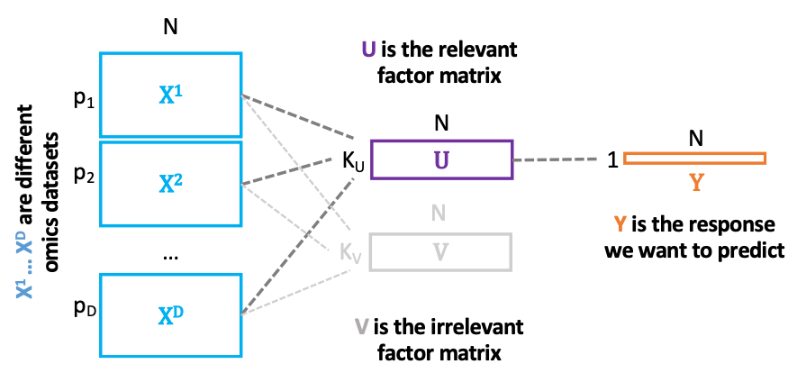

SPEAR overview

```r
# Get factor contributions for each factor generated by SPEAR. Will return:
#   factor.contributions: the exact contribution amounts per factor
#   relevant.factors:     which factors are deemed "relevant" (contribution > threshold, .01 by default)
#   threshold:   the cutoff used to determine which factors are "relevant"
SPEAR.get_factor_contributions(SPEARobj, threshold = .01)
```

```
## $factor.contributions
##         GausResponse
## Factor1  0.235909762
## Factor2  0.281535690
## Factor3  0.005031167
## Factor4 -0.001629956
## Factor5 -0.005474465
##
## $relevant.factors
##      [,1]
## [1,]    1
## [2,]    1
## [3,]    0
## [4,]    0
## [5,]    0
##
## $threshold
## [1] 0.01
```

We can also plot the factor contributions for visualization:

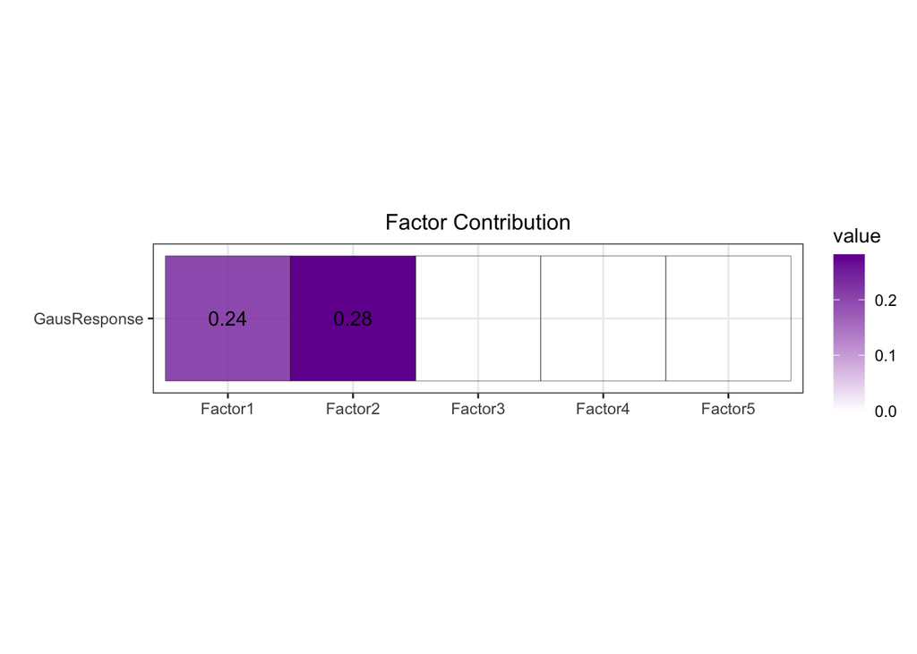

```r
# Plot factor contributions:
#     threshold: cutoff used to determine factor relevance
#     show.irrelevant: if FALSE, will only plot relevant factor contributions
#     show.labels: show numeric contributions in plot?
SPEAR.plot_factor_contributions(SPEARobj, threshold = .01, show.irrelevant = FALSE, show.labels = TRUE)
```

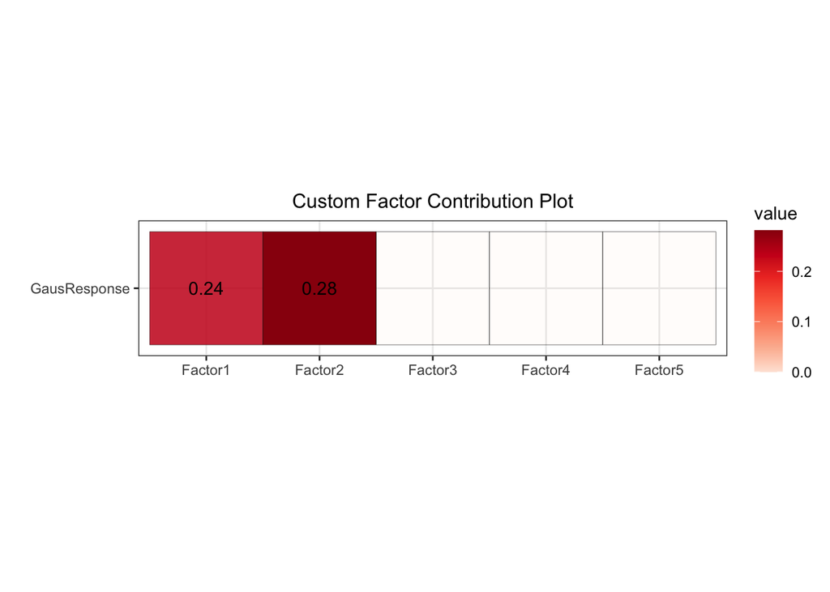

```r
# As a quick aside, plotting functions all return ggplot grob objects, and can be easily edited as such:
plot <- SPEAR.plot_factor_contributions(SPEARobj, threshold = .01, show.irrelevant = FALSE, show.labels = TRUE)
plot +
  scale_fill_distiller(palette = "Reds", direction = 1) +
  ggtitle("Custom Factor Contribution Plot")
```

### Cross-validation results:

Here, we can analyze the results from running the cross-validated version of SPEAR.

First, we check the prediction error:

```r
# Get cross-validated prediction error
#    show.all.w - show cvm for all weights? Best weight is found by lowest cvm
#  (similar to SPEARobj$cv.eval$cvm)
SPEAR.get_cv_prediction_error(SPEARobj, show.all.w = TRUE)
```

```
##       GausResponse   w
##  [1,]    0.4944720 2.0
##  [2,]    0.4981857 1.8
##  [3,]    0.5017476 1.6
##  [4,]    0.5043119 1.4
##  [5,]    0.5095206 1.2
##  [6,]    0.5107142 1.0
##  [7,]    0.5117544 0.8
##  [8,]    0.5800579 0.6
##  [9,]    0.6153796 0.4
## [10,]    0.5981328 0.2
## [11,]    0.5949315 0.0
```

Plotting the cross-validation predictions:

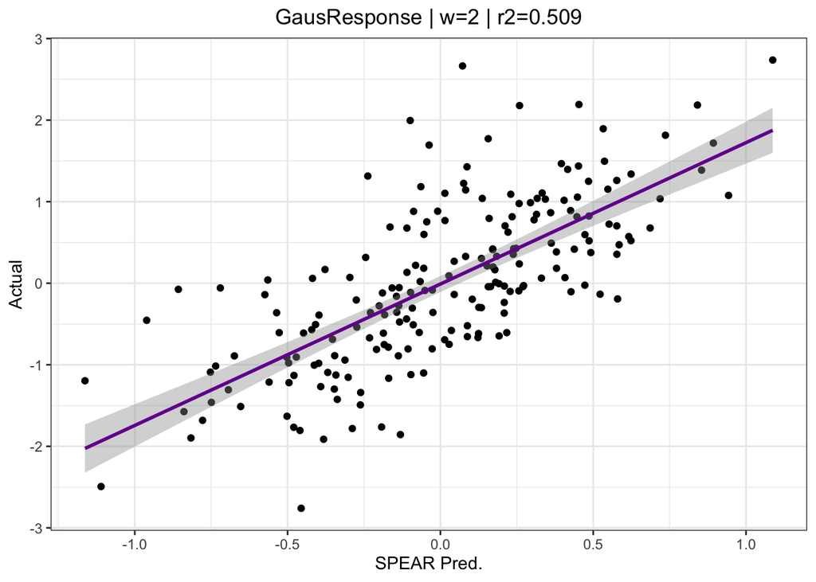

```r
# Plot cv predictions for the best weight:
SPEAR.plot_cv_predictions(SPEARobj)
```

Finally, if we want to extract the SPEAR predictions, we use the functions below. Note that there are options for which weight to use (as a different value of ‘w’ means different factors, and different predictions). The SPEAR predictons to be used per response should be the weight with the lowest cvm (i.e. ‘best’ or ‘overall’)

```r
# Get actual predictions:
#  w - which weight to use?
#  'best' will return lowest cvm per response.
#  'overall' returns the lowest cvm overall. When only measuring one response, 'best' is the same as 'overall'.
#  'all' returns a list with each prediction for each value of 'w'.
spear.predictions.best <- SPEAR.get_cv_predictions(SPEARobj, w = "best")
spear.predictions.overall <- SPEAR.get_cv_predictions(SPEARobj, w = "all")
spear.predictions.all <- SPEAR.get_cv_predictions(SPEARobj, w = "all")

print(spear.predictions.best$predictions[1:10])
```

```
##  [1]  0.47297784  0.15282769 -0.35301873 -0.42092507  0.04520657  0.29462612
##  [7] -0.39725054 -0.05489622  0.07243083  0.21147792
```

### Using Factor Scores

We can try to interpret our factors by looking at the distributions of factor scores. We can also split our subjects into groups (based on response, clinical data, etc.) and see if there are any major differences in factor scores between groups.

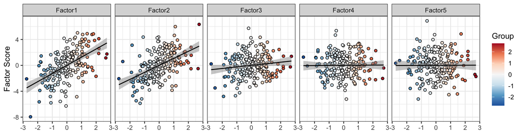

```r
# First, set up a named vector called 'groups'. Set names(groups) to be the subject for each grouping variable:

# Example of setting up a continuous 'groups' vector:
# Use the response as the variable we want to plot:
groups <- SPEARobj$data$Y
# Set the names of the vector to be the samples they correspond to (make sure they are ordered correctly)
names(groups) <- rownames(SPEARobj$data$Y)


# Plot the factor scores:
SPEAR.plot_factor_scores(SPEARobj, groups = groups)
```

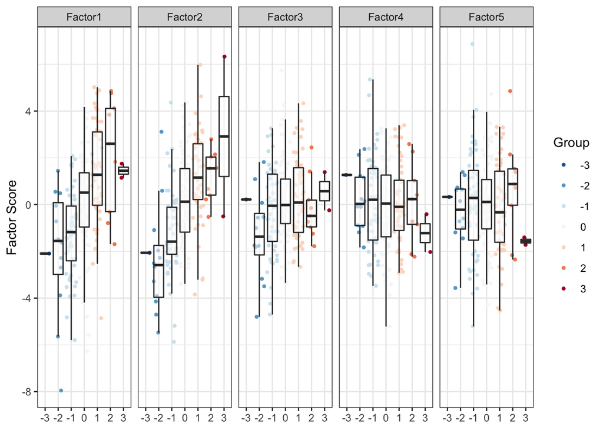

```r
# Lets convert the continuous response into ordinal (bins)
# Use the response as the variable we want to plot:
groups <- round(SPEARobj$data$Y, 0)
groups <- factor(as.character(groups), levels = as.character(unique(sort(groups))))
# Set the names of the vector to be the samples they correspond to (make sure they are ordered correctly)
names(groups) <- rownames(SPEARobj$data$Y)


# Plot the factor scores:
SPEAR.plot_factor_scores(SPEARobj, groups = groups)
```

We can also plot a matrix grid of factor scores, with the diagonal representing the distributions of factor scores:

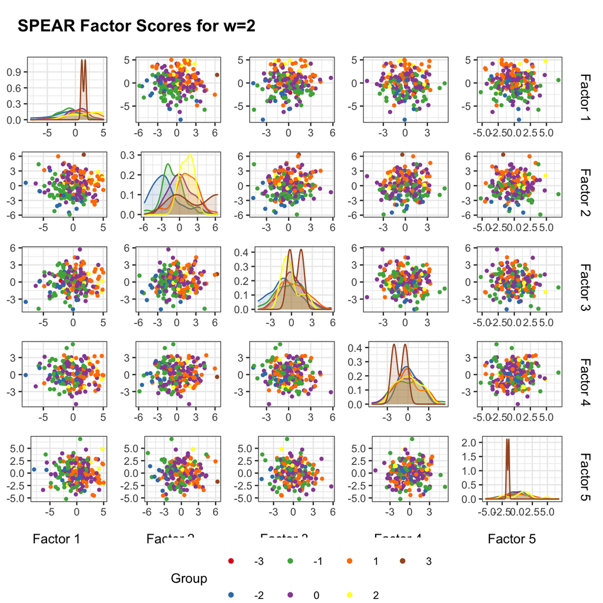

```r
SPEAR.plot_factor_grid(SPEARobj, groups = groups)
```

We can choose to only plot a subset of factors: (i.e. the relevant factors)

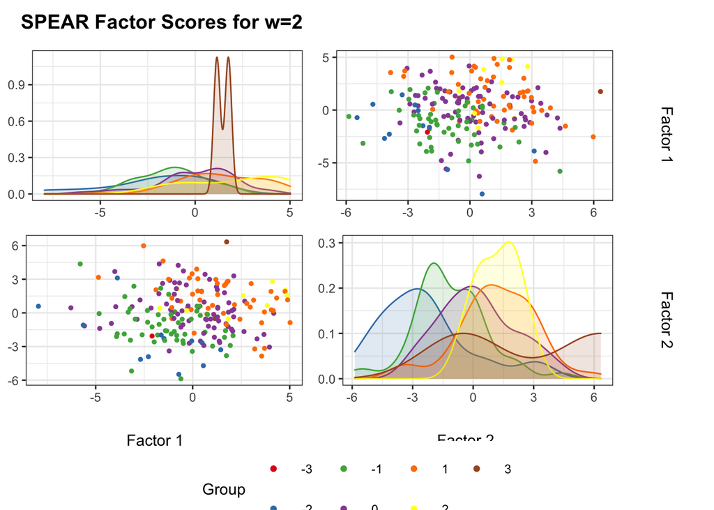

```r
relevant.factors.to.Y <- which(SPEAR.get_factor_contributions(SPEARobj)$relevant.factors == 1)
SPEAR.plot_factor_grid(SPEARobj, groups = groups, factors = relevant.factors.to.Y)
```

Finally, we can look into factor scores vs. the cv-predictions from SPEAR:

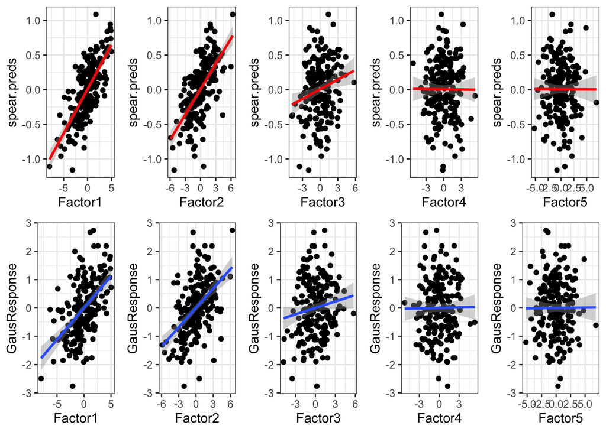

```r
# This will plot two rows of plots:
# top row - Factor Scores (X axis) vs. SPEAR CV Predictions
# bottom row - Factor Scores (X axis) vs. True response (SPEARobj$data$Y)

f.scores <- SPEAR.get_factor_scores(SPEARobj)$GausResponse$factor.scores
spear.preds <- SPEAR.get_cv_predictions(SPEARobj)
y <- SPEARobj$data$Y
df <- data.frame(Factor1 = f.scores[,1],
                 Factor2 = f.scores[,2],
                 Factor3 = f.scores[,3],
                 Factor4 = f.scores[,4],
                 Factor5 = f.scores[,5], # Assuming 5 factors were used
                 spear.preds = unname(spear.preds$predictions),
                 GausResponse = y)

plots <- list()
# Versus the predicted values from SPEAR:
for(k in 1:SPEARobj$params$num_factors){
  g <- ggplot(df) +
    geom_point(aes_string(x = paste0("Factor", k), y = "spear.preds")) +
    geom_smooth(aes_string(x = paste0("Factor", k), y = "spear.preds"), method = "lm", color = "red") +
    theme_bw()
  plots[[k]] <- g
}
# Versus the actual response data:
for(k in 1:SPEARobj$params$num_factors){
  g <- ggplot(df) +
    geom_point(aes_string(x = paste0("Factor", k), y = "GausResponse")) +
    geom_smooth(aes_string(x = paste0("Factor", k), y = "GausResponse"), method = "lm") +
    theme_bw()
  plots[[SPEARobj$params$num_factors + k]] <- g
}
cowplot::plot_grid(plotlist = plots, nrow = 2)
```

### Feature Inspection

Now that we have an idea about the factor scores themselves, we can try to figure out what features from X influence each factor. This can be done by inspecting the factor loadings matrix. This is a P x K matrix (P = total number of features from ALL X datasets, K = number of factors generated by SPEAR). Each feature is assigned a posterior selection probability from 0-1. From here, a cut-off (typically .5) can be made to select relevant features per factor (i.e. if probability >= .5).

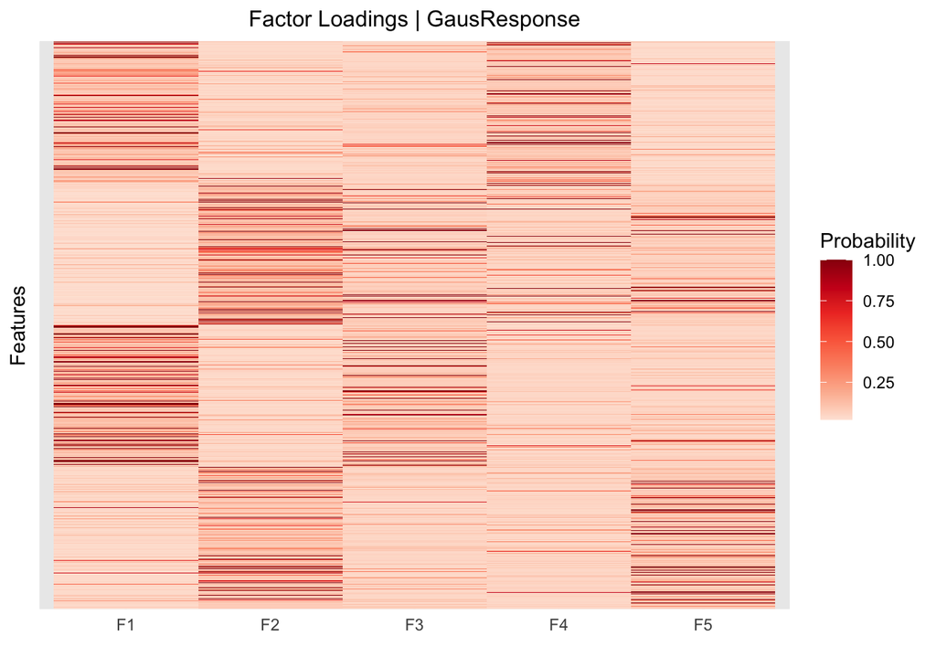

```r
# Plot all factor loadings
#     plot.irrelevant.factors - should factors that aren't relevant to predicting Y be shown?
SPEAR.plot_factor_loadings(SPEARobj, plot.irrelevant.factors = TRUE)
```

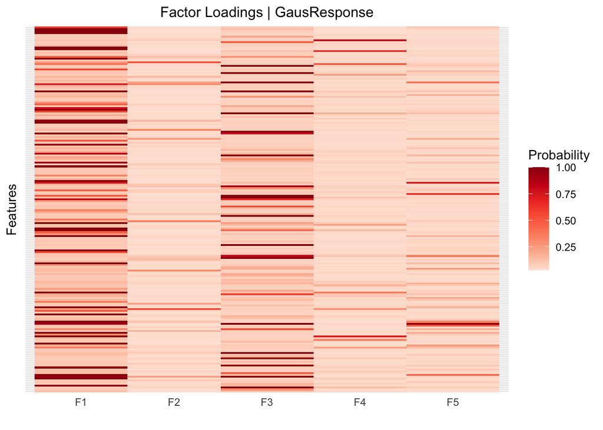

```r
# Can choose to plot per omic as well
#     plot.per.omic - make a different plot for each omic (matrix in X), rather than returning one plot with all features
#     return.list - return a list of ggplot2 grob objects instead of a plot.
SPEAR.plots <- SPEAR.plot_factor_loadings(SPEARobj, plot.per.omic = TRUE, plot.irrelevant.factors = TRUE, return.list = TRUE)
SPEAR.plots[[2]]
```

We can get the names of the features and probabilities for each factor with the function below. Data will be returned as a list:

Y - colnames(SPEARobj$data$Y) + Factors - names of factors found to be relevant for that response (i.e. Factor1, Factor2) + X - names of omics datasets that have at least one feature associated with the response + features - vector of relevant features (pulled from the column names of X passed into SPEAR) + probabilities - named list of posterior selection probabilities of features, names = features

```r
# Get the names of features contributing to relevant factors
#   cutoff - posterior probability selection cutoff, features with probabilities higher than 'cutoff' will be added to the list
#   threshold - minimum factor contribution to be deemed "relevant"
feature.list <- SPEAR.get_factor_features(SPEARobj, cutoff = .5, threshold = .01)
names(feature.list) # show relevant factors per response
```

```
## [1] "GausResponse"
```

### SPEAR predicting new (testing) data

If a testing dataset has been set aside from the data SPEAR was trained on, you can use a trained SPEAR model to predict responses for the new data. This testing data is required to have the same number of features (columns) in X as the training dataset.

```r
# Below uses simulated data generated in the SPEAR_simulate_data.Rmd
path_to_sim_data <- getwd() # Replace with the path to the 'simulated_gaussian_data.rds' file
sim.data <- readRDS(paste0(path_to_sim_data, "/simulated_gaussian_data.rds"))


Xtest <- sim.data$data.te$xlist # replace with your testing data here
Ytest <- sim.data$data.te$Y     # replace with your testing data response if you have it here

# Make sure the dimensions of the test data match the dimensions of the training data
sapply(SPEARobj$data$xlist, ncol)
```

```
## OmicsData1 OmicsData2 OmicsData3 OmicsData4
##        200        200        200        200
```

```r
sapply(Xtest, ncol)
```

```
## [1] 200 200 200 200
```

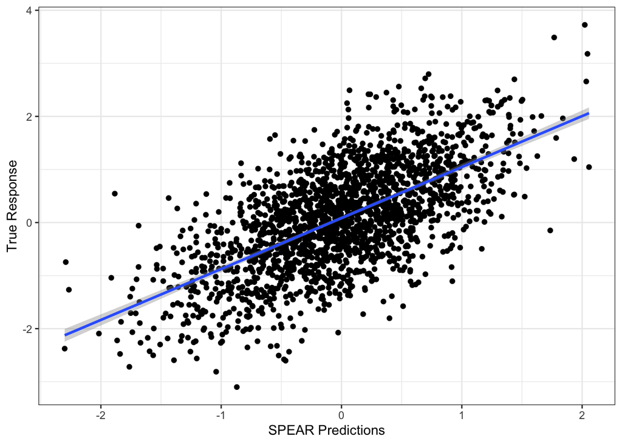

```r
# Get predictions:
SPEARpreds <- SPEAR.predict_new_samples(SPEARobj, Xtest, scale.x = TRUE)
# Below is the same thing in case you want to work directly with the matrices:
#SPEARpreds <- scale(data.total$data.te$X) %*% SPEARobj$cv.eval$reg_coefs[,1,,which.min(SPEARobj$cv.eval$cvm)] + SPEARobj$cv.eval$intercepts[[1]][which.min(SPEARobj$cv.eval$cvm),]
SPEARpreds <- SPEARpreds$predictions
truth <- Ytest
# Plot predictions:
g <- ggplot() +
  geom_point(aes(x = SPEARpreds, y = truth)) +
  geom_smooth(aes(x = SPEARpreds, y = truth), method = "lm") +
  xlab("SPEAR Predictions") +
  ylab("True Response") +
  theme_bw()
g
```